# Enhanced Deterministic Gated Item Response Model to Simultaneously Identify Compromised Items and Examinees with Item Preknowledge Using Response Accuracy Data

Cengiz Zopluoglu

University of Oregon

12/6/2024

[Updated: Thu, Dec 19, 2024 - 10:50:59 ]

# Acknowledgement

This tutorial is a product of a research project funded by Duolingo, Inc. through Competitive Research Grant Program to support topics of interest related to Duolingo’s English Test’s ongoing research agenda.

# Introduction

This tutorial provides a detailed introduction to an enhanced version of the model initially introduced by [Shu et al. (2023)](https://doi.org/10.1007/s11336-012-9311-3). The original model assumed that the compromised status of items was known beforehand. It focused on estimating whether an examinee had item preknowledge, given a predefined vector indicating the compromise status of items using response accuracy. Follow up studies such as [Eckerly (2016)](https://uoregon.idm.oclc.org/login?url=https://www.proquest.com/dissertations-theses/increasing-robustness-deterministic-gated-irt/docview/1817649033/se-2?accountid=14698) showed that the performance the model drops when the vector of item compromise status is misspecified.

In the enhanced version presented here, the requirement for prior knowledge of item compromise status is removed. Instead, both examinee status and item compromise status are treated as unknown parameters to be estimated simultaneously. This upgraded model outputs two probabilities in a single analysis: the probability that an examinee has item preknowledge and the probability that an item is compromised.

# Model Description

This section describes the model fitted to the response accuracy data using the following notations:

- Items are indexed by $i = 1,...,I$,
- Examinees are indexed by $j = 1,...,J$
- For the $j^{th}$ examinee, $\mathbf{R}_j = (\mathrm{R}_{j1}, \ldots, \mathrm{R}_{jI})$ represents a vector of dichotomous item responses for $I$ items, with realizations $\mathbf{r}_j = (\mathrm{r}_{j1}, \ldots, \mathrm{r}_{jI})$.
- For the $i^{th}$ item, item difficulty parameter is denoted as $b_i \in \mathbb{R}$.

The proposed model defines two latent trait parameters for each examinee:

- $\theta_{tj} \in \mathbb{R}$: The true latent trait when the $j^{th}$ examinee responds to an item without prior knowledge.
- $\theta_{cj} \in \mathbb{R}$: The cheating latent trait when the examinee responds to an item with prior knowledge.

Additionally, we define:

- A binary parameter for each examinee to indicate item preknowledge status, $H_j$, where $H_j = 0$ means the examinee is honest and does not have item preknowledge, and $H_j = 1$ means the examinee is dishonest and has item preknowledge.
- A binary parameter for each item to indicate compromise status, $C_i$, where $C_i = 0$ means the item is not compromised, and $C_i = 1$ means the item is compromised.

An observed binary response (1 for correct, 0 for incorrect) of the $j^{th}$ examinee on the $i^{th}$ item is assumed to follow the distribution:

$$R_{ij} \sim f(r_{ij}; \theta_{tj},
\theta_{cj}, H_j, b_i, C_i).$$
Here, $f(r_{ij}; \theta_{tj}, \theta_{cj}, H_j, b_i, C_i)$ denotes a Bernoulli probability function with a success parameter:

$$P(r_{ij} = 1 \mid \theta_{tj},
\theta_{cj}, H_j, b_i, C_i) = \frac{1}{1 + e^{b_i -
\theta_j}},$$

where $\theta_j$ is defined as:

$$\theta_j =
\begin{cases}
\theta_{cj}, & \text{if } H_j = 1 \text{ and } C_i = 1, \\
\theta_{tj}, & \text{otherwise}.
\end{cases}$$

Since Stan does not directly handle discrete parameters, marginalization of $H_j$ and $C_i$ is required. This involves summing over the four possible combinations of $H_j$ and $C_i$:

- $H_j = 0, C_i = 0$: Honest examinee responds to an uncompromised item.
- $H_j = 1, C_i = 0$: Dishonest examinee responds to an uncompromised item.
- $H_j = 0, C_i = 1$: Honest examinee responds to a compromised item.
- $H_j = 1, C_i = 1$: Dishonest examinee responds to a compromised item.

The probability density can be expressed as:

$$f(r_{ij}; \theta_{tj}, \theta_{cj}, H_j,
b_i, C_i) = \sum_{H_j, C_i} f(r_{ij}; \theta_{tj}, \theta_{cj}, H_j,
b_i, C_i) \cdot P(H_j) \cdot P(C_i).$$

The model assumes that $\theta_{cj} > \theta_{tj}$ for any examinee, ensuring proper chain convergence and reducing the chance of label switching. The item difficulty parameters are scaled such that their sum equals zero.

Latent trait parameters are modeled as a multivariate normal distribution:

$$\begin{pmatrix} \theta_{tj},\theta_{cj}
\end{pmatrix} \sim N(\mu_{\theta}, \Sigma_{\theta}),$$

where $\Sigma_{\theta}$ is decomposed into standard deviations and a correlation matrix:

$$\Sigma_{\theta} =
\begin{pmatrix}
\sigma_{\theta_t} & 0 \\
0 & \sigma_{\theta_c} \end{pmatrix}
\Omega_{\theta}
\begin{pmatrix} \sigma_{\theta_t} & 0 \\
0 & \sigma_{\theta_c} \end{pmatrix},$$

$$\Omega_{\theta} =
\begin{pmatrix}
1 & \rho_{\theta_t,\theta_c} \\
\rho_{\theta_t,\theta_c} & 1 \end{pmatrix}.$$

The priors distributions for the person parameters are specified as follows:

$$\mu_{\theta_t}, \mu_{\theta_c} \sim N(0,
1),$$

$$\sigma_{\theta_t}, \sigma_{\theta_c}
\sim \text{Exponential}(1),$$

$$\Omega_{\theta} \sim
\text{LKJ}(1).$$

The item difficulty parameters for (I - 1) items are assumed to follow a normal distribution.

$$\mathbf{b} \sim
N(\mu_b,\sigma_b),$$
with $\mu_b$ is the mean and $\sigma_b$ is the standard deviation of item difficulty parameters for (I - 1) items,

$$\mu_b\sim
N\left(0,1\right),$$

$$\sigma_b\sim
exponential\left(1\right).$$

The value of the item difficulty for the remaining item is determined by computing the negative sum of the item difficulty parameters for (I - 1) items.

The prior for the probabilities of $P(H_j = 1)$ and $P(C_i = 1)$ are specified as:

$$P(H_j = 1) \sim \text{Beta}(1, 1)$$

$$P(C_i = 1) \sim \text{Beta}(1, 1)$$

# Stan Model Syntax

The data block defines the structure and input data required for the model. It assumes that the data is provided in a long format, which is particularly advantageous for handling missing responses in sparse datasets. In this format, the data has at least a column for subject IDs (e.g., examinee identifiers), a column for item IDs, and another column for observed dichotomous responses.

```r
data{
    int <lower=1> J;                       // number of examinees
    int <lower=1> I;                       // number of items
    int <lower=1> n_obs;                   // number of observations (I xJ - missing responses)
    array[n_obs] int<lower=1> p_loc;       // person indicator
    array[n_obs] int<lower=1> i_loc;       // item indicator
    array[n_obs] int<lower=0, upper=1> Y;  // vector of item responses
}
```

The parameters and transformed parameters block specifies all the parameters required by the model.

```r
parameters {
  real mu_thetat;             // mean for theta_t
  real<lower=0> sigma_thetat; // sd for theta_t

  real mu_thetac;             // mean for theta_c
  real<lower=0> sigma_thetac; // sd for theta_c

  corr_matrix[2] omega_P;    // 2 x 2 correlation matrix for person parameters

  vector<lower=0,upper=1>[I] pC; // vector of length I for the probability of item compromise status

  vector<lower=0,upper=1>[J] pH; // vector of length J for the probability of examinee item peknowledge

  array[J] ordered[2] person;          // an array with length J for person specific latent parameters
                                 // Each array has two elements
                                 // first element is theta_t
                                 // second element is theta_c
                                 // ordered vector assures that theta_c > theta_t for every person
                                 // to make sure chains are exploring the same mode and
                                 // multiple chains do not go east and west leading multi-modal posteriors

  real mu_b;                  // mean for item difficulty parameters
  real<lower=0> sigma_b;      // sd for item difficulty parameters
  vector[I-1] b_star;         // vector of item difficulty parameters

}
```

```r
transformed parameters{

  vector[2] mu_P;             // vector for mean vector of person parameters
    mu_P[1] = mu_thetat;      // mu_thetat;
    mu_P[2] = mu_thetac;      // mu_thetac;

  vector[2] scale_P;          // vector of standard deviations for person parameters
   scale_P[1] = sigma_thetat;
   scale_P[2] = sigma_thetac;

  // If you want to constrain the correlation between theta_t and theta_c to 0
    // matrix[2,2] omega_P_constrained = omega_P;
    // omega_P_constrained[1,2]=0;
    // omega_P_constrained[2,1]=0;

  cov_matrix[2] Sigma_P;      // covariance matrix for person parameters
   Sigma_P = quad_form_diag(omega_P, scale_P);

  vector[I] b;    // vector of item difficulty parameters
    b[2:I] = b_star;
    b[1]   = -sum(b_star);
}
```

In the **parameters block**, I used `array[J] ordered[2] person;` to define the array for person-specific parameters instead of a simple `vector[2] person[J]`. The ordered type in Stan ensures that the elements of the vector are ordered, with the first element being smaller than the second. Specifically, in this case, it enforces that $\theta_c > \theta_t$ for every individual.

This constraint may help in reducing the chance of multi-modal posterior distributions due to label switching (a common phenomena for models with mixture type). Without this enforced order, the model is more prone to multi-modal posterior distributions. This problem arise when different Markov Chain Monte Carlo (MCMC) chains explore different modes in opposite directions, leading to incoherent results and difficulties in interpretation. Below provides an example of this issue. We will also supplement this order constrain with an additional strategy to avoid label switching as much as possible.

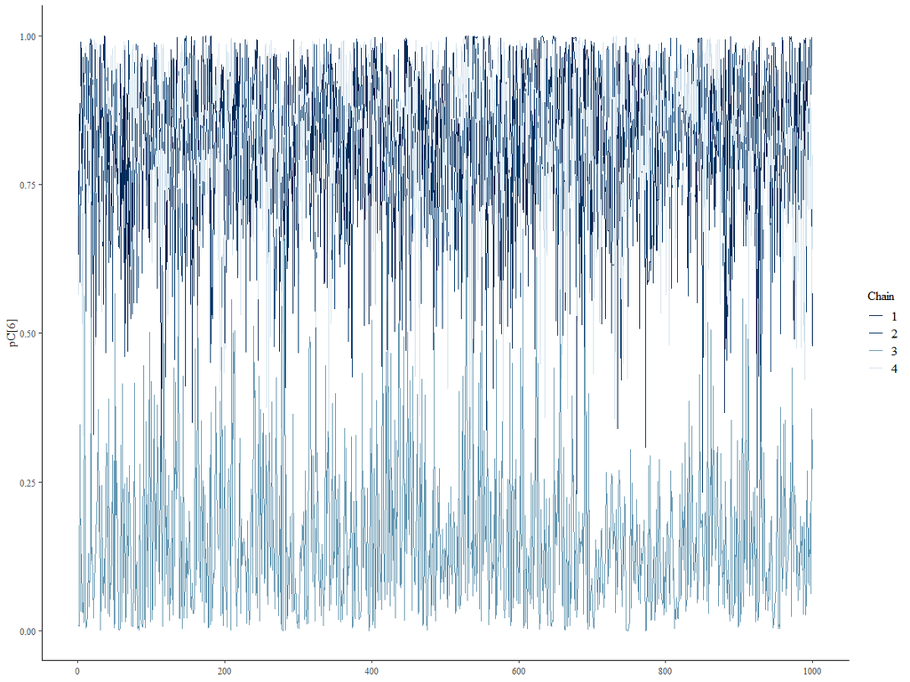

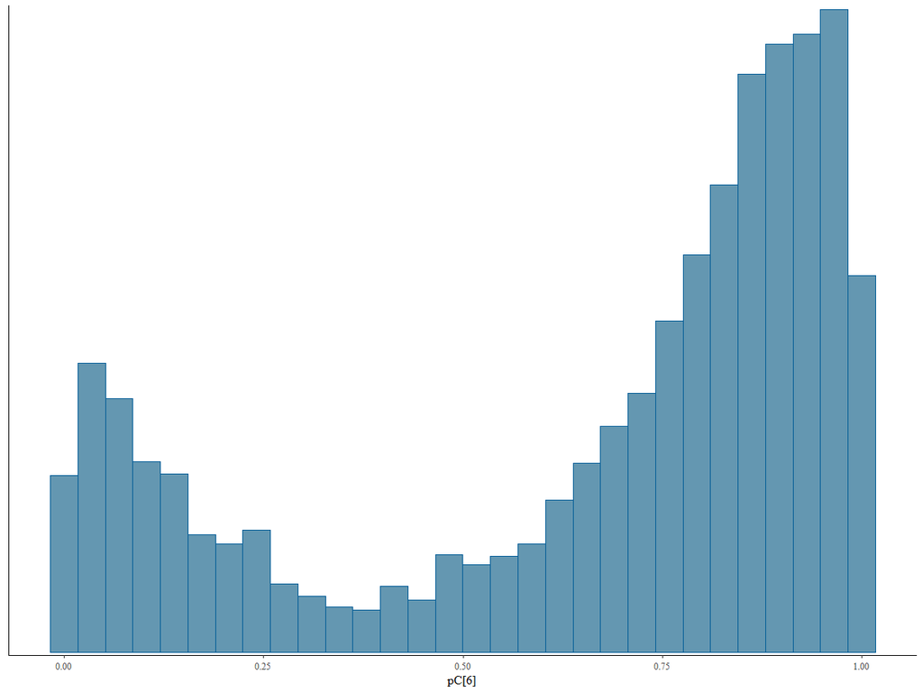

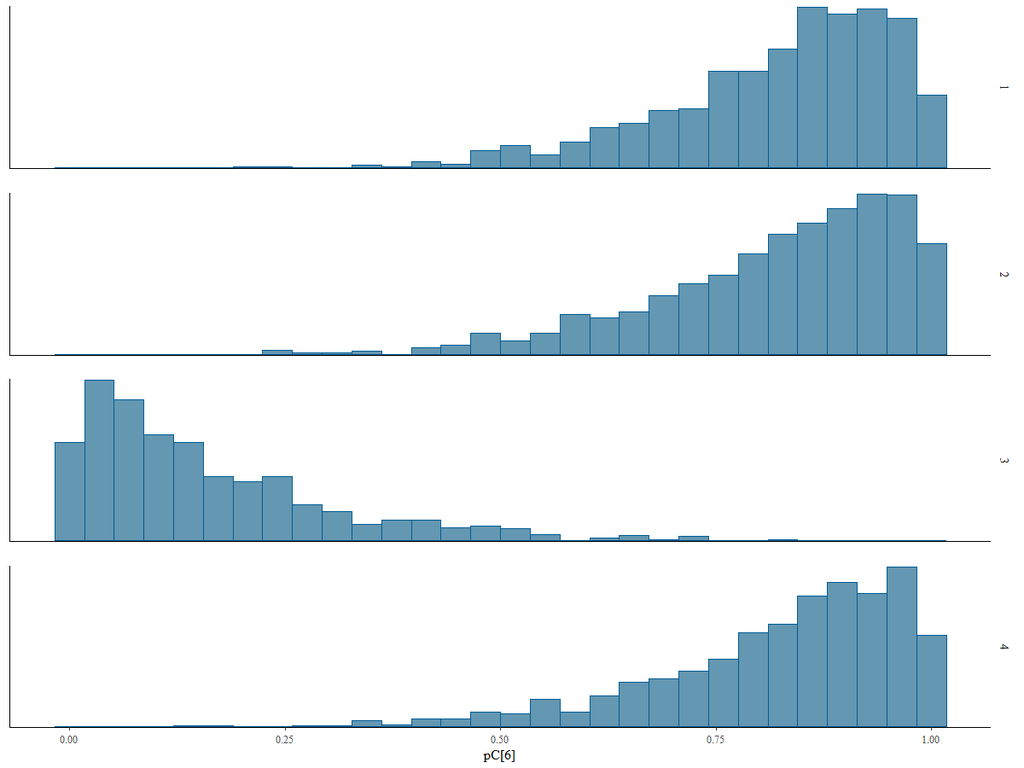

Finally, we specify the prior distributions and model in the **model block**.

```r
model{

  mu_thetat     ~ normal(0,1);
  sigma_thetat  ~ exponential(1);

  mu_thetac     ~ normal(0,1);
  sigma_thetac  ~ exponential(1);

  omega_P       ~ lkj_corr(1);

  person        ~ multi_normal(mu_P,Sigma_P);

  mu_b      ~ normal(0,1);
  sigma_b   ~ exponential(1);
  b_star    ~ normal(mu_b,sigma_b);

  pC ~ beta(1,1);
  pH ~ beta(1,1);

  for (i in 1:n_obs) {

      // b[i_loc[i]] represents b-parameter of the (i_loc[i])th item
      //person[p_loc[i],1] represents parameter theta_t of the (p_loc[i])th person
      //person[p_loc[i],2] represents parameter theta_c of the (p_loc[i])th person


      real p_t = person[p_loc[i],1] - b[i_loc[i]];  // non-cheating response
      real p_c = person[p_loc[i],2] - b[i_loc[i]];  // cheating response

      // log of probability densities for each combination of two discrete parameters
      // (C,T) = {(0,0),(0,1),(1,0),(1,1)}

      real lprt1 = log1m(pC[i_loc[i]]) + log1m(pH[p_loc[i]]) + bernoulli_logit_lpmf(Y[i] | p_t);  // H = 0, C=0
      real lprt2 = log1m(pC[i_loc[i]]) + log(pH[p_loc[i]])   + bernoulli_logit_lpmf(Y[i] | p_t);  // H = 1, C=0
      real lprt3 = log(pC[i_loc[i]])   + log1m(pH[p_loc[i]]) + bernoulli_logit_lpmf(Y[i] | p_t);  // H = 0, C=1
      real lprt4 = log(pC[i_loc[i]])   + log(pH[p_loc[i]])   + bernoulli_logit_lpmf(Y[i] | p_c);  // H = 1, C=1

      target += log_sum_exp([lprt1, lprt2, lprt3, lprt4]);
  }
}
```

The whole Stan syntax for the model can be saved as a stan file ([Download the Stan model syntax](https://raw.githubusercontent.com/czopluoglu/duolingo_dgirt/refs/heads/main/script/dgirt.stan)).

# Data Generation

To test the model’s performance, I will simulate a dataset based on the following specifications:

- 500 hypothetical examinees respond to 50 items.
- 50 examinees (10% of all examinees) have item preknowledge for 15 items (30% of items)
- The item difficulty parameters are drawn from a standard normal distribution.
- The true and cheating latent speed parameters $\theta_t$ and $\theta_c$ are drawn from a multivariate distribution with the following values:

$$\begin{pmatrix}
\theta_t \\ \theta_c
\end{pmatrix}
\sim
N(\mu_{\mathcal{\theta}}, \Sigma_{\mathcal{\theta}})$$

$$\mu_{\mathcal{P}} =
\begin{pmatrix}
0 \\ 3
\end{pmatrix}$$

$$\Sigma_{\mathcal{P}} =
\begin{pmatrix}
1 & 0.8 \\
0.8 & 1.25
\end{pmatrix}$$

The covariance matrix implies a correlation of 0.716 between $\theta_t$ and $\theta_c$. The code below generates observed dichotomous response accuracy data consistent with these specifications.

```r
require(MASS)
require(MBESS)
require(here)
require(psych)
require(pROC)
set.seed(7122024)
################################################################################
# Generate model parameters

N  <- 500     # sample size
n  <- 50      # number of items
pe <- 0.10    # proportion of examinees with item preknowledge
pi <- 0.30    # proportion of compromised items

# Generate the binary status of examinee item preknowledge
  # 1: examinee has item preknowledge
  # 0: examinee has item preknowledge

  tmp <- runif(N,0,1)
  H  <- ifelse(tmp<=quantile(tmp,pe),1,0)
  H
  table(H)

# Generate the binary status of item compromise
  # 1: item is compromised
  # 0: item is not compromised

  tmp <- runif(n,0,1)
  C  <- ifelse(tmp<=quantile(tmp,pi),1,0)
  C
  table(C)

# Generate item difficulty parameters

  b <- rnorm(n,0,1)
  b <- (b-mean(b))/sd(b)
  b
  describe(b)

# Generate person parameters

  mu_t    <- 0      # mean of true latent trait parameters
  mu_c    <- 3      # mean of cheating latent trait parameters
  sigma_t <- 1      # standard dev. of true latent trait parameters
  sigma_c <- 1.25   # standard dev. of cheating latent trait parameters
  cov_    <- 0.8    # covariance between cheating and true latent trait parameters

        1/(1+exp(-mu_t)) # probability of correct for average item without preknowledge
        1/(1+exp(-mu_c)) # probability of correct for average item with preknowledge

        # some rough idea about effect size, item preknowledge effect
        # Odds ratio
          exp(mu_c)/exp(mu_t)


  th <- mvrnorm(N,
                mu = c(mu_t,mu_c),
                Sigma = matrix(c(sigma_t,cov_,cov_,sigma_c),2,2))

  theta_t <- th[,1]
  theta_c <- th[,2]

  describe(theta_t)
  describe(theta_c)
  describe(theta_c - theta_t)
  cor(theta_t,theta_c)

###############################################################################
# Generate observed responses

r <- matrix(nrow=N,ncol=n)

for(j in 1:N){
  for(i in 1:n){

    p_t <- exp(theta_t[j] - b[i])/(1+exp(theta_t[j] - b[i]))
    p_c <- exp(theta_c[j] - b[i])/(1+exp(theta_c[j] - b[i]))

    if(H[j] == 1 & C[i] == 1){
      r[j,i] = rbinom(1,1,p_c)
    } else {
      r[j,i] = rbinom(1,1,p_t)
    }

  }
}

colnames(r) <- paste0("Y",1:n)
###############################################################################

# Convert it to data frame and add group membership and a unique ID

d       <- as.data.frame(r)
d$group <- H
d$id    <- 1:nrow(d)

# Check the data

head(d)

# Reshape it to long format

d.long <- reshape(data        = d,
                  idvar       = 'id',
                  varying     = list(colnames(r)[1:n]),
                  timevar     = "Item",
                  times       = 1:n,
                  v.names     = c("R"),
                  direction   = "long")

d.long <- d.long[!is.na(d.long$R),]

# Add item status

d.long$compromised <- NA

for(i in 1:n){

  d.long[d.long$Item==i,]$compromised = C[i]

}


d.long <- d.long[order(d.long$Item),]

describeBy(d.long$R,list(d.long$group,d.long$compromised),mat=TRUE)

################################################################################

write.csv(d.long,'./data/simdata_long.csv',
          row.names = FALSE)

write.csv(d,'./data/simdata_wide.csv',
          row.names = FALSE)
```

## Checking the simulated dataset

The table below shows the proportion of correct responses for hypothetical examinees in the simulated dataset, grouped by whether they had prior knowledge of the items, for both compromised and uncompromised items. As expected, the proportion of correct responses is similar for both groups on uncompromised items. However, examinees with prior knowledge respond more accurately on compromised items.

| Compromised Status | Item Number | Honest Group Mean | Dishonest Group Mean |
| --- | --- | --- | --- |
| Uncompromised | 1 | 0.38 | 0.3 |
| Uncompromised | 3 | 0.59 | 0.62 |
| Uncompromised | 5 | 0.66 | 0.64 |
| Uncompromised | 7 | 0.65 | 0.62 |
| Uncompromised | 8 | 0.52 | 0.46 |
| Uncompromised | 10 | 0.43 | 0.4 |
| Uncompromised | 11 | 0.79 | 0.74 |
| Uncompromised | 15 | 0.27 | 0.32 |
| Uncompromised | 16 | 0.17 | 0.1 |
| Uncompromised | 18 | 0.33 | 0.38 |

[output cut: 40 more lines]

# Fitting the model

The first step is to structure the input data in a list format. This is required because Stan accepts data in a specific format for model fitting. Each element in the list corresponds to a variable used in the Stan model.

```r
data_resp <- list(
  I              = length(unique(d_long$Item)),
  J              = length(unique(d_long$id)),
  n_obs          = nrow(d_long),
  p_loc          = d_long$id,
  i_loc          = d_long$Item,
  Y              = d_long$R
)
```

Before fitting the model, the Stan syntax (.stan file) needs to be compiled into a format that can be executed. This step creates a cmdstan_model object.

```r
# Compile the model syntax
mod <- cmdstan_model('./script/dgirt.stan')
```

## Single chain initialization

In addition to the order constraints ($\theta_c > \theta_t$), discussed earlier, I am also employing a single chain initialization strategy as a complementary approach to further mitigate the risk of label switching. By initializing the parameters near plausible values within the vicinity of a single mode, this method helps stabilize the sampling process and reduces the likelihood of components switching labels during inference. While the order constraint enforces a structural restriction to break the symmetry of the mixture components, single chain initialization adds an extra layer of robustness by anchoring the chains to a specific mode early in the sampling process. Together, these strategies work in tandem to address the challenges posed by label switching, ensuring more reliable and interpretable posterior inferences. For more information, see [this link](https://mc-stan.org/docs/stan-users-guide/problematic-posteriors.html#hacks-as-fixes).

The code below fits the model using a single chain and relatively fewer iterations.

```r
fit_init <- mod$sample(
  data            = data_resp,
  chains          = 1,
  iter_warmup     = 150,
  iter_sampling   = 150,
  refresh         = 10,
  adapt_delta     = 0.99)
```

Once we fit the model with a single chain, we extract the model parameters and we will feed these values as starting parameters in the next stage.

## Multi-chain estimation

```r
# a vector of initial item difficulty parameters

b_start <- as.vector(fit_init$summary("b")$mean)

# a two column matrix of initial theta parameters

theta <- data.frame(thetat = fit_init$summary("person")$mean[1:500],
                    thetac = fit_init$summary("person")$mean[501:1000])
rownames(theta) <- NULL
colnames(theta) <- NULL

# A vector of initial P(H=1) parameters, probability of an examinee having item preknowledge

as.vector(fit_init$summary("pH")$mean)

# A vector of initial P(C=1) parameters, probability of an item being compromised

C <- as.vector(fit_init$summary("pC")$mean)

# Put the initial estimates together as a list

start <- list(b      = b_start,
              person = theta,
              pH     = H,
              pC     = C)
```

```r
fit <- mod$sample(
  data            = data_resp,
  seed            = 1234,
  chains          = 4,
  parallel_chains = 4,
  iter_warmup     = 500,
  iter_sampling   = 1000,
  refresh         = 10,
  init            = list(start,start,start,start),
  adapt_delta     = 0.99)


# Save the model object with all parameters for future use or backup

fit$save_object(file = "./do_not_upload/model_fit.RDS")
```

# Model Convergence

Ensuring model convergence is essential to verify the reliability of posterior estimates. This section outlines the evaluation of convergence diagnostics for different types of parameters in the model. The analysis follows the robust workflow detailed in Michael Betancourt’s [Robust Statistical Worflow with RStan](https://betanalpha.github.io/assets/case_studies/rstan_workflow.html).

```r
# Extract model summary
model_summary <- as.data.frame(fit$summary(variables = c("b","person","pC","pH")))

# Add a column for parameter types extracted from row names
model_summary$type <- gsub("\\[.*$", "", model_summary$variable)

head(model_summary)
```

```
  variable       mean     median        sd       mad          q5        q95
1     b[1]  0.3302467  0.3171415 0.1586698 0.1516322  0.09190912  0.6075988
2     b[2]  0.8973555  0.8991220 0.1776073 0.1753301  0.60700280  1.1874920
3     b[3] -0.4623348 -0.4668580 0.2109263 0.2137590 -0.80166120 -0.1031135
4     b[4] -0.7058011 -0.6981615 0.1660419 0.1656628 -0.99386400 -0.4458681
5     b[5] -0.9335390 -0.9398665 0.1849834 0.1839647 -1.22310100 -0.6075277
6     b[6]  1.8193172  1.8221750 0.3240650 0.3303974  1.26982650  2.3425840
       rhat ess_bulk ess_tail type
1 0.9999079 2666.516 2552.820    b
2 1.0020326 1213.040 1893.925    b
3 1.0010650 1770.747 2647.351    b
4 1.0009015 3448.766 2765.551    b
5 1.0009836 1992.748 2801.353    b
6 1.0029788 1232.798 1740.364    b
```

- The `summary()` function extracts posterior summaries from the fitted model.
- The `gsub()` function removes index annotations (e.g., [1], [2,1]) from parameter names to group parameters by type.

The `model_summary` can be used for further diagnostics.

## Effective Sample Sizes

The minimum size of **effective samples per iteration** is 0.109 for item difficulty parameter estimates, 0.107 for person parameter estimates, 0.203 for probability of item compromise (pC), and 0.367 for probability of having item preknowledge(pH). They are all far above the threshold 0.001, indicating no problem in terms of estimating the effective sample sizes.

```r
iter <- 4000    # number of chains x number of sampling iterations

model_summary$n_eff_ratio <- model_summary[,'ess_bulk'] / iter

psych::describeBy(model_summary$n_eff_ratio,
                  model_summary$type,
                  mat=TRUE)[,c('group1','min')]
```

```
    group1       min
X11      b 0.1092636
X12     pC 0.2031587
X13 person 0.1069865
X14     pH 0.3674522
```

The summary of effective sample sizes by each parameter type is below.

```r
  psych::describeBy(model_summary$ess_bulk,
                    model_summary$type,
                    mat=TRUE)[,c('group1','mean','min','max')]
```

```
    group1     mean       min      max
X11      b 2033.156  437.0545 3803.507
X12     pC 1641.571  812.6350 2622.629
X13 person 2901.492  427.9459 6318.522
X14     pH 3694.782 1469.8090 6146.714
```

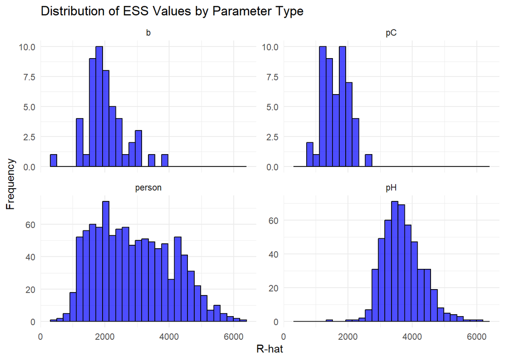

```r
# Create a histogram of ESS values grouped by parameter type
  ggplot(model_summary, aes(x = ess_bulk)) +
    geom_histogram(fill = "blue", color = "black", alpha = 0.7) +
    facet_wrap(~type, scales = "free_y",nrow=2) +
    labs(
      title = "Distribution of ESS Values by Parameter Type",
      x = "R-hat",
      y = "Frequency"
    ) +
    theme_minimal()
```

## Split Rhat summary by Parameter type

All parameters exhibit excellent convergence with R-hat values less than 1.01. The highest R-hat value observed is 1.009.

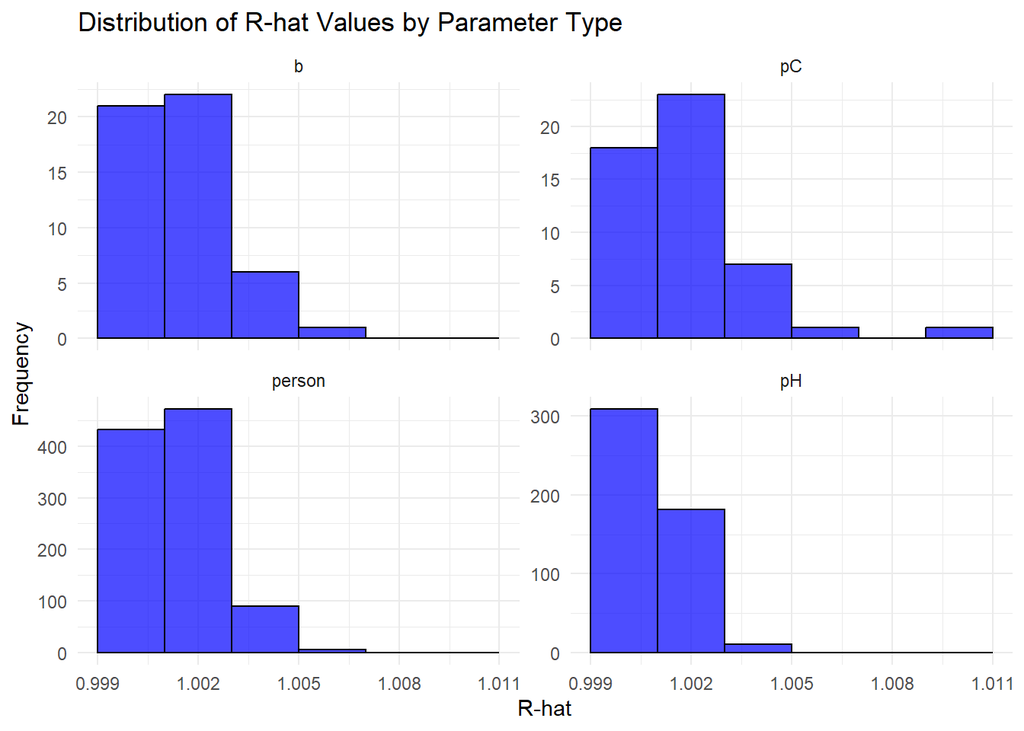

```r
# Create a histogram of Rhat values grouped by parameter type
ggplot(model_summary, aes(x = rhat)) +
    geom_histogram(binwidth = 0.002, fill = "blue", color = "black", alpha = 0.7) +
    facet_wrap(~type, scales = "free_y",nrow=2) +
    labs(
      title = "Distribution of R-hat Values by Parameter Type",
      x = "R-hat",
      y = "Frequency"
    ) +
    theme_minimal()
```

```r
  psych::describeBy(model_summary$rhat,
                    model_summary$type,
                    mat=TRUE)[,c('group1','mean','min','max')]
```

```
    group1     mean       min      max
X11      b 1.001545 0.9997130 1.006514
X12     pC 1.001906 0.9996119 1.009002
X13 person 1.001375 0.9994399 1.008824
X14     pH 1.000885 0.9992906 1.004805
```

```r
  sum(model_summary$Rhat<1.01)/nrow(model_summary)
```

```
[1] 0
```

## Tree Depth

The results of the tree depth analysis indicate that none of the 4,000 post-warmup iterations saturated the maximum tree depth of 10 (0%). The majority of iterations achieved a tree depth of 7 (79.1%), with a smaller number reaching a tree depth of 8 (20.9%). This suggests that the sampler operated efficiently and did not encounter issues related to trajectory length limits during the model fit. No further adjustment to the max_treedepth parameter is necessary.

```r
# Sampler diagnostics
sampler_params <- posterior::as_draws_df(fit$sampler_diagnostics())

# Tree depths across iterations
table(sampler_params$treedepth__)
```

```
   7    8
3165  835
```

## E-BFMI

E-BMFI values were above 0.2 for all chains, the recommended threshold to flag inefficient exploration of the parameter space. There was no red flag in terms of potential inefficiencies in the exploration of the parameter space across the chains. Specifically:

- Chain 1: E-BFMI = 0.4163
- Chain 2: E-BFMI = 0.3207
- Chain 3: E-BFMI = 0.3974
- Chain 4: E-BFMI = 0.3754

```r
e_bfmi <- c()
  for (n in 1:4) {
    energies = sampler_params[sampler_params$.chain==n,]$energy__
    numer = sum(diff(energies)**2) / length(energies)
    denom = var(energies)
    e_bfmi[n] = numer / denom
    print(sprintf('Chain %s: E-BFMI = %s', n, numer / denom))
  }
```

```
[1] "Chain 1: E-BFMI = 0.416336642244791"
[1] "Chain 2: E-BFMI = 0.320724267736608"
[1] "Chain 3: E-BFMI = 0.397359348326614"
[1] "Chain 4: E-BFMI = 0.375399339230667"
```

## Divergences

The divergence diagnostic for this model fit indicates no divergent transitions out of the total iterations (0%). This result suggests that the Hamiltonian Monte Carlo sampler explored the posterior distribution effectively, encountering no problematic regions or pathological neighborhoods.

```r
100 * mean(sampler_params$divergent__)
```

```
[1] 0
```

# Parameter Estimates

## Person Parameter Estimates

The true latent trait parameter estimates ($\theta_t$) have a mean of -0.44 and a standard deviation of 0.96. In contrast, the cheating latent trait parameter estimates ($\theta_c$) exhibit a higher mean of 2.54 with a standard deviation of 0.82.

```r
theta <- matrix(fit$summary(variables = c("person"))$mean,ncol=2,byrow=FALSE)
psych::describe(theta)
```

```
   vars   n  mean   sd median trimmed  mad   min  max range skew kurtosis   se
X1    1 500 -0.44 0.96  -0.44   -0.44 0.94 -2.84 2.28  5.12 0.04    -0.25 0.04
X2    2 500  2.54 0.82   2.51    2.54 0.83  0.33 4.59  4.26 0.01    -0.39 0.04
```

|  | Parameter | Posterior Mean | Posterior SD | 5% | 95% | Rhat | ESS |
| --- | --- | --- | --- | --- | --- | --- | --- |
| 1 | person[1,1] | 0.4778629541492 | 0.4100821297873598 | -0.21160635 | 1.125109 | 1.003398649686707 | 4579.066900724026 |
| 2 | person[2,1] | -1.838818134 | 0.583575056605938 | -2.852769 | -0.9658189500000006 | 1.000693468619611 | 2108.985530277443 |
| 3 | person[3,1] | 0.727517928563 | 0.4243406155521895 | 0.03686130000000001 | 1.4294195 | 1.000560966586551 | 3372.104045727183 |
| 4 | person[4,1] | -1.20029816317 | 0.4968449188971532 | -2.052216 | -0.4449768000000005 | 1.000481777161906 | 2891.711466723706 |
| 5 | person[5,1] | 0.84532458537 | 0.4117156090865983 | 0.1653753000000001 | 1.517006 | 1.000377710052282 | 4302.19637607841 |
| 6 | person[6,1] | -0.73885170588175 | 0.4783982347535231 | -1.5572205 | 0.01627061499999948 | 1.000502174237544 | 4253.367899026658 |
| 7 | person[7,1] | 0.9145897569675 | 0.3883596480519249 | 0.281 | 1.5397635 | 1.000371138441902 | 4804.826962020189 |
| 8 | person[8,1] | -0.2870068320615 | 0.3842964156583014 | -0.95459915 | 0.3103582499999998 | 1.001527778383624 | 4285.913977591394 |
| 9 | person[9,1] | -0.432720624222025 | 0.3455442986980212 | -1.029633 | 0.1151078499999999 | 1.001340669670391 | 5851.110132880189 |
| 10 | person[10,1] | -0.87678785984875 | 0.4296481101530462 | -1.6082425 | -0.2247833500000003 | 0.9998901835823423 | 4579.727462816892 |

[output cut: 490 more lines]

|  | Parameter | Posterior Mean | Posterior SD | 5% | 95% | Rhat | ESS |
| --- | --- | --- | --- | --- | --- | --- | --- |
| 1 | person[1,2] | 3.05324081675 | 1.072668098291328 | 1.458866 | 4.995887999999999 | 1.000377459985754 | 1986.409659765364 |
| 2 | person[2,2] | 1.3418325376525 | 0.9928549290662492 | -0.06323183999999998 | 3.22402 | 1.001194997239386 | 2400.307146094132 |
| 3 | person[3,2] | 3.825166607 | 1.065972414339126 | 2.1698795 | 5.6877515 | 1.002441233847684 | 1696.476462232945 |
| 4 | person[4,2] | 2.771061202725 | 0.9031519572209243 | 1.370003 | 4.337038999999997 | 1.001141928531358 | 1356.729817055318 |
| 5 | person[5,2] | 3.24015526825 | 1.123101114593729 | 1.648103 | 5.318068499999998 | 0.9999900884134103 | 2028.777470981937 |
| 6 | person[6,2] | 3.67571199625 | 0.8703827919471574 | 2.369574 | 5.183361499999999 | 1.005535668189644 | 1302.24398119107 |
| 7 | person[7,2] | 3.2456378914225 | 1.152503362209561 | 1.536795 | 5.298438999999999 | 1.002011203764277 | 1954.696750769035 |
| 8 | person[8,2] | 2.469350465395 | 1.122606348916429 | 0.75317985 | 4.4151 | 1.001482688625764 | 1741.117237902104 |
| 9 | person[9,2] | 2.24090730448 | 1.173035578313132 | 0.4166952 | 4.2636305 | 1.000349865368357 | 2317.534456415262 |
| 10 | person[10,2] | 1.88049722372525 | 1.128035657913228 | 0.1668346 | 3.852309999999999 | 1.000152663647212 | 3346.559055002292 |

[output cut: 490 more lines]

## Item Parameters

The item difficulty parameter estimates, $b$, has a mean of 0 with a standard deviation of 1.12.

```r
  b <- fit$summary(variables = c("b"))
  psych::describe(b$mean)
```

```
   vars  n mean   sd median trimmed  mad   min  max range skew kurtosis   se
X1    1 50    0 1.12  -0.31   -0.11 0.95 -1.79 3.26  5.04 0.84     0.34 0.16
```

|  | Parameter | Posterior Mean | Posterior SD | 5% | 95% | Rhat | ESS |
| --- | --- | --- | --- | --- | --- | --- | --- |
| 1 | b[1] | 0.330246694115 | 0.1586697699046019 | 0.09190912 | 0.6075988499999998 | 0.9999078823419602 | 2666.515674936726 |
| 2 | b[2] | 0.897355493 | 0.1776073178129582 | 0.6070028 | 1.187492 | 1.002032588795807 | 1213.039509823623 |
| 3 | b[3] | -0.462334847825275 | 0.2109262908061117 | -0.8016612000000001 | -0.1031135000000002 | 1.001065016430949 | 1770.74691421127 |
| 4 | b[4] | -0.70580106165 | 0.1660419168494247 | -0.993864 | -0.4458681000000001 | 1.000901462397746 | 3448.765751057832 |
| 5 | b[5] | -0.93353897625 | 0.1849833966832735 | -1.223101 | -0.6075276500000002 | 1.000983558934572 | 1992.748296817437 |
| 6 | b[6] | 1.81931722225 | 0.3240650438673346 | 1.2698265 | 2.342584 | 1.002978774864646 | 1232.79778188307 |
| 7 | b[7] | -0.906125787375 | 0.18519694716109 | -1.1955405 | -0.5945975000000001 | 1.000936156979478 | 2048.428433849712 |
| 8 | b[8] | -0.2985027142871 | 0.1712322614381777 | -0.56104065 | 0.004583225499999834 | 1.001555483845438 | 1654.461635295264 |
| 9 | b[9] | 3.25540606 | 0.3482177397804438 | 2.6832005 | 3.829791 | 1.000997783685859 | 1193.3468528741 |
| 10 | b[10] | 0.387506756422 | 0.2193621231608748 | 0.03954214 | 0.7569059999999999 | 1.003262096433948 | 1367.511547392738 |

[output cut: 40 more lines]

## Interpreting P(C=1) and evaluating predictive performance in detecting compromised items

Two groups of items were clearly separated by the probability estimates of being compromised. The probabilities ranged from 0.05 to 0.83 with a mean of 0.27 and standard deviation of 0.16 for uncompromised items (group1 = 0), and ranged from 0.66 to 0.93 with a mean of 0.86 and standard deviation of 0.086 for compromised items (group1 = 1).

```r
# Retrive the true item compromise status
# from long format data

C_vec <- c()

for(kk in 1:50){
  C_vec[kk] = unique(d.long[d.long$Item==kk,]$compromised)
}

pC <- fit$summary(variables = c("pC"))$mean

psych::describeBy(pC,C_vec,mat=TRUE)[,c('group1','n','mean','sd','min','max')]
```

```
    group1  n      mean         sd        min       max
X11      0 35 0.2714224 0.16173781 0.05357169 0.8287202
X12      1 15 0.8553196 0.08583614 0.65917136 0.9308771
```

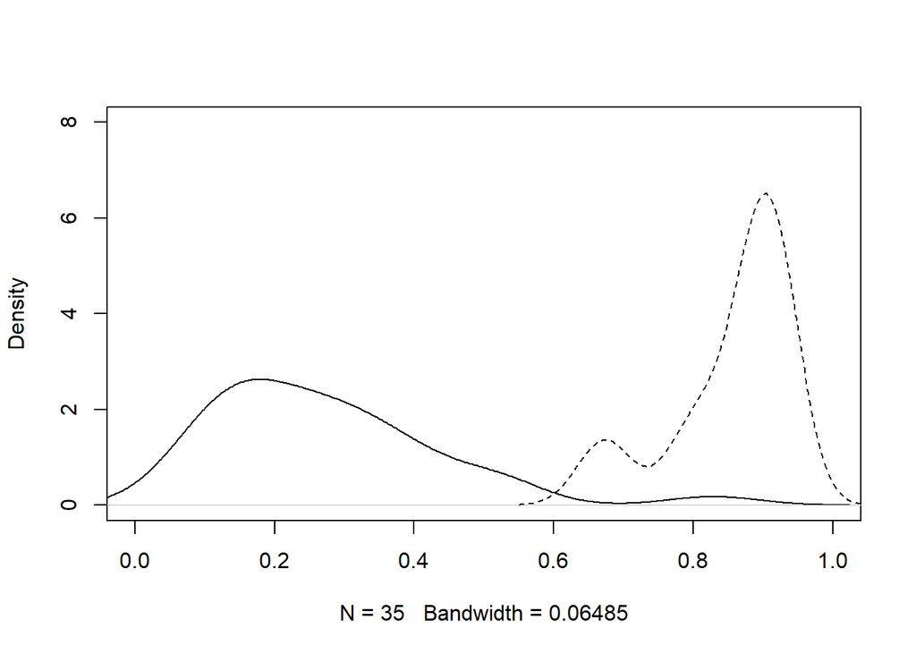

```r
plot(density(pC[C_vec==0]),xlim=c(0,1),main="",ylim = c(0,8))
points(density(pC[C_vec==1]),lty=2,type='l')
```

As a numerical measure, the Area Under the Curve (AUC) was 0.99, indicating an almost perfect separation between compromised and uncompromised items.

```r
require(pROC)

auc(C_vec,pC)
```

```
Area under the curve: 0.9924
```

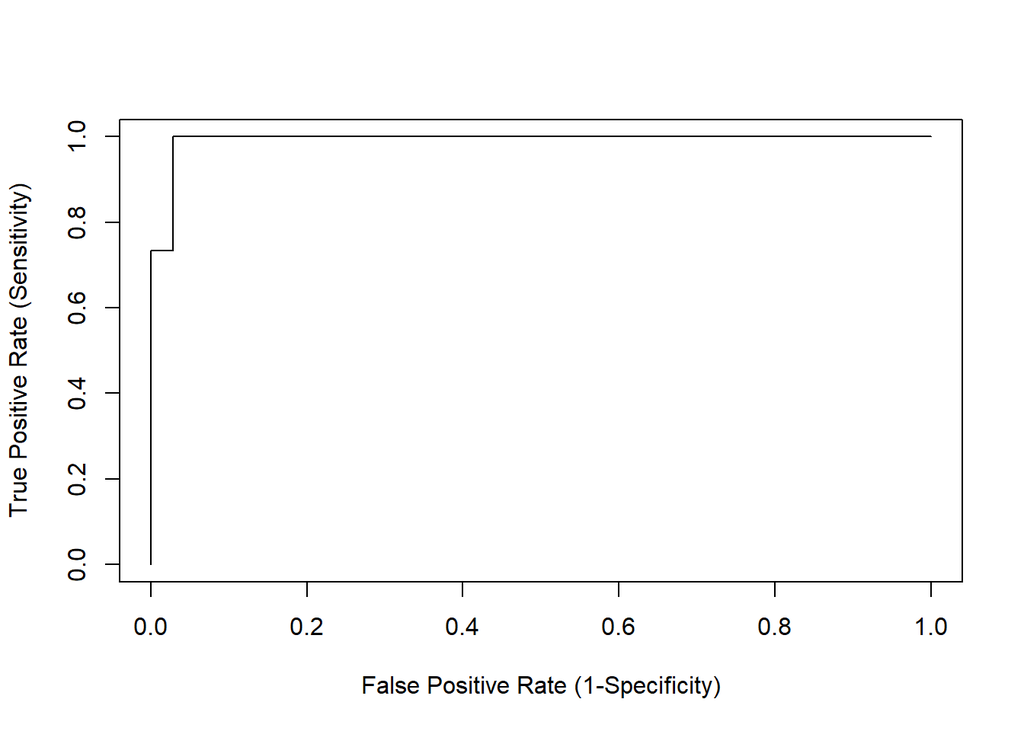

```r
roc_analysis <- roc(response = C_vec,
                    predictor = pC)

plot(1-roc_analysis$specificities,
     roc_analysis$sensitivities,
     xlim = c(0,1),ylim=c(0,1),
     xlab = 'False Positive Rate (1-Specificity)',
     ylab = 'True Positive Rate (Sensitivity)',
     type='l')
```

```r
my_thresholds <- seq(from=0.5,to=0.8,by=0.01)

coords(roc_analysis,
       my_thresholds,
       input="threshold",
       ret=c("threshold","specificity", "sensitivity"))
```

```
   threshold specificity sensitivity
1       0.50   0.8857143   1.0000000
2       0.51   0.9142857   1.0000000
3       0.52   0.9142857   1.0000000
4       0.53   0.9428571   1.0000000
5       0.54   0.9714286   1.0000000
6       0.55   0.9714286   1.0000000
7       0.56   0.9714286   1.0000000
8       0.57   0.9714286   1.0000000
9       0.58   0.9714286   1.0000000
10      0.59   0.9714286   1.0000000
11      0.60   0.9714286   1.0000000
12      0.61   0.9714286   1.0000000
13      0.62   0.9714286   1.0000000
14      0.63   0.9714286   1.0000000
```

[output cut: 17 more lines]

|  | Parameter | Posterior Mean | Posterior SD | 5% | 95% | Rhat | ESS |
| --- | --- | --- | --- | --- | --- | --- | --- |
| 1 | pC[1] | 0.114029044826425 | 0.08733443274643397 | 0.008369764000000002 | 0.28422295 | 1.000445572039111 | 2292.813474216416 |
| 2 | pC[2] | 0.9265944525 | 0.06544205350319031 | 0.7949526 | 0.9956081 | 1.000455213766151 | 1970.189118169584 |
| 3 | pC[3] | 0.4082294285875 | 0.1691587985151222 | 0.1165171 | 0.67555915 | 1.001344481473897 | 1313.321645929451 |
| 4 | pC[4] | 0.898271542 | 0.08885997314643772 | 0.7232843 | 0.99331055 | 1.000473629003978 | 1855.209624955875 |
| 5 | pC[5] | 0.30467317290025 | 0.1602326643380328 | 0.05279394500000002 | 0.5767988999999998 | 1.003187656345437 | 1508.351799833338 |
| 6 | pC[6] | 0.687538115 | 0.1705745535475361 | 0.39371175 | 0.95755915 | 1.004905738934525 | 847.06496528672 |
| 7 | pC[7] | 0.2763711775385 | 0.1596020817606684 | 0.03620863500000002 | 0.5593712 | 1.002407497917241 | 1436.783229055036 |
| 8 | pC[8] | 0.200886073730725 | 0.1257687667731678 | 0.02380542 | 0.4340662999999998 | 1.002313245672757 | 1310.326929883831 |
| 9 | pC[9] | 0.6591713565 | 0.1654576559673062 | 0.39375685 | 0.93680725 | 1.009002168080514 | 812.6349831249122 |
| 10 | pC[10] | 0.3666094810235 | 0.1408241234884401 | 0.12632905 | 0.5970922 | 1.005872823903238 | 1080.813825212574 |

[output cut: 40 more lines]

## Interpreting P(H=1) and evaluating predictive performance in detecting simulees with item preknowledge

Two groups of examinees were also clearly separated by the probability estimates of examinees having item preknowledge, indicating that model successfully picked up the signal in the simulated dataset. The probabilities ranged from 0.16 to 0.83 with a mean of 0.46 and standard deviation of 0.14 for honest simulees (group1 = 0), and ranged from 0.60 to 0.90 with a mean of 0.82 and standard deviation of 0.08 for dishonest simulees (group1 = 1).

```r
  pH <- fit$summary(variables = c("pH"))$mean

  psych::describeBy(pH,d$group,mat=TRUE)[,c('group1','n','mean','sd','min','max')]
```

```
    group1   n      mean         sd       min       max
X11      0 450 0.4564859 0.13973033 0.1623490 0.8287395
X12      1  50 0.8158812 0.07825421 0.5967449 0.8998434
```

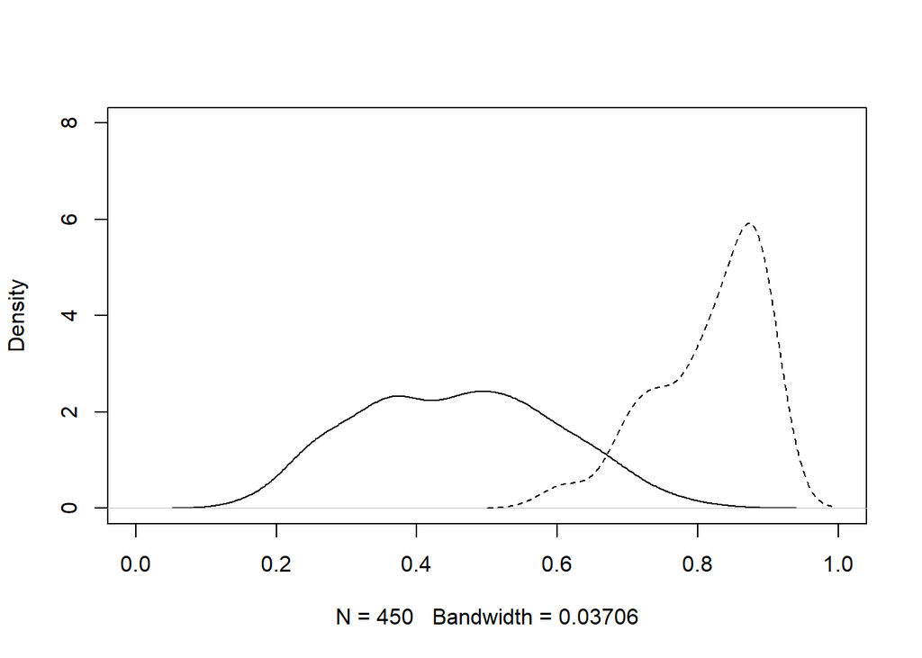

```r
  plot(density(pH[d$group==0]),xlim=c(0,1),main="",ylim = c(0,8))
  points(density(pH[d$group==1]),lty=2,type='l')
```

As a numerical measure, the Area Under the Curve (AUC) was 0.987, indicating a very strong separation between groups with and without item preknowledge by the probability estimates.

```r
  auc(d$group,pH)
```

```
Area under the curve: 0.9868
```

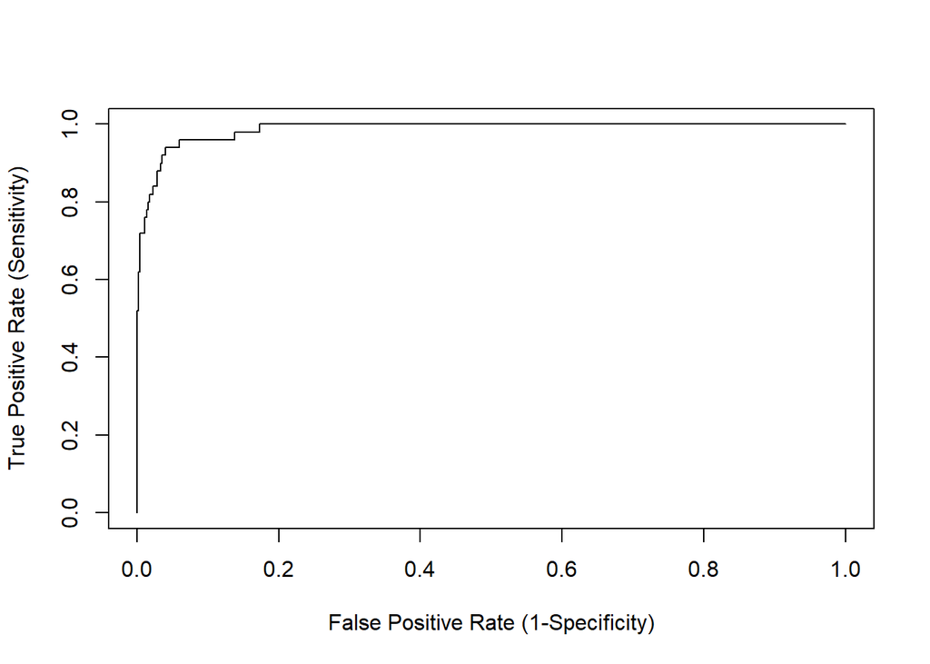

```r
  roc_analysis <- roc(response = d$group,
                      predictor = pH)

  plot(1-roc_analysis$specificities,
       roc_analysis$sensitivities,
       xlim = c(0,1),ylim=c(0,1),
       xlab = 'False Positive Rate (1-Specificity)',
       ylab = 'True Positive Rate (Sensitivity)',
       type='l')
```

```r
  my_thresholds <- seq(from=0.5,to=0.8,by=0.01)

  coords(roc_analysis,
         my_thresholds,
         input="threshold",
         ret=c("threshold","specificity", "sensitivity"))
```

```
   threshold specificity sensitivity
1       0.50   0.6000000        1.00
2       0.51   0.6444444        1.00
3       0.52   0.6600000        1.00
4       0.53   0.6800000        1.00
5       0.54   0.6955556        1.00
6       0.55   0.7288889        1.00
7       0.56   0.7600000        1.00
8       0.57   0.7800000        1.00
9       0.58   0.7955556        1.00
10      0.59   0.8111111        1.00
11      0.60   0.8288889        0.98
12      0.61   0.8511111        0.98
13      0.62   0.8622222        0.98
14      0.63   0.8755556        0.96
```

[output cut: 17 more lines]

|  | Parameter | Posterior Mean | Posterior SD | 5% | 95% | Rhat | ESS |
| --- | --- | --- | --- | --- | --- | --- | --- |
| 1 | pH[1] | 0.4379518849982 | 0.2538981260666645 | 0.05469695500000001 | 0.8818139999999997 | 1.000109603462479 | 3566.596081615187 |
| 2 | pH[2] | 0.5596496776975 | 0.2535076290992009 | 0.12175845 | 0.94407265 | 1.001321192404156 | 3064.764375351282 |
| 3 | pH[3] | 0.588449147588575 | 0.2416623801010992 | 0.14473885 | 0.9390230499999999 | 1.001360148243944 | 3333.980326410981 |
| 4 | pH[4] | 0.74844324455 | 0.1755176282468423 | 0.41132385 | 0.9766762499999999 | 1.00127727142936 | 3236.591288356205 |
| 5 | pH[5] | 0.47160842674675 | 0.2759425984089232 | 0.05126454 | 0.9269616499999999 | 1.003628298360577 | 4400.475343335678 |
| 6 | pH[6] | 0.87383603825 | 0.1077860550071311 | 0.6646217000000001 | 0.9912924 | 1.00026240393325 | 4027.601987631385 |
| 7 | pH[7] | 0.39033195196375 | 0.2673375866013751 | 0.02841753000000001 | 0.8757316500000001 | 1.00050514217275 | 4603.346715824327 |
| 8 | pH[8] | 0.36387522654375 | 0.2333032357376764 | 0.03667315 | 0.8019129 | 1.001553796494675 | 3173.524165224267 |
| 9 | pH[9] | 0.246750530615725 | 0.2071071448159949 | 0.01530053 | 0.6798552999999999 | 0.9999674259234832 | 4277.935790386787 |
| 10 | pH[10] | 0.364549366853 | 0.2516503122532078 | 0.033558515 | 0.8602522499999996 | 1.000342453735378 | 3720.555330615073 |

[output cut: 490 more lines]